# Rを用いたデータ解析の 基礎とその実践

※石川由希博士（名古屋大学）が作製した資料を再構成したものです。  
※資料の一部は岩嵜航博士（東北大学）が作製したものです。  
（左右キーで進みます！）

## 研究の基本プロセスはいつも一緒

### 1. 課題を見つける／仮説を立てる

### 2. 実験や観察をしてデータを集める

### 3. **データを整理する**

### 4. **データを解析して仮説を検証する**

- 実験や観察は研究の半分くらい！
- 残り半分はデータの整理＆解析！
- 解析によっては宝石になるはずのデータも単なる石ころに…！

## 科学の営み = 巨人の肩に立つ

### 先人たちの積み重ねに基づいて、新しい発見をする

### **記録を残すことは何より重要**

- 実験や野外観察では些細なことも漏らさず記録。
- 生データは何重にもバックアップ。

### **データ整理・解析・作図も不可欠。だけど…**

- 再現不能の職人技で切り抜けてしまう人も多い。
- コピペ、メニュー選択、配色と配置を微調整…

### **猜疑が生じたら…？別の人が研究を発展させたいとき…？**

❌「ありまぁす！」  
⭕「誰でも確実に再現できるプロトコルがこちらです」

## 再現不可能な職人的研究の例…

- 動物園の混合展示で、各動物がどのように分布・行動しているか。それらを決める要因は何か。
- 膨大な観察データに基づく超大作卒論。

[figure not shown]

## 生データ：ここはまだそんなに悪くない

- 週に１回、各個体の位置と行動を種ごとのファイルに記録。
- タブは個体、A,B列はXY座標でそれ以降は行動、各行は時刻。

[figure not shown]

## コピペを駆使して条件ごとに複製・集計

- ちゃんと合ってるのかな…ファイルもタブもたくさん…
- どこから何をコピーしてたのか、もはや思い出せない…

[figure not shown]

## コピペを駆使して条件ごとに複製・集計

- ちゃんと合ってるのかな…ファイルもタブもたくさん…
- どこから何をコピーしてたのか、もはや思い出せない…

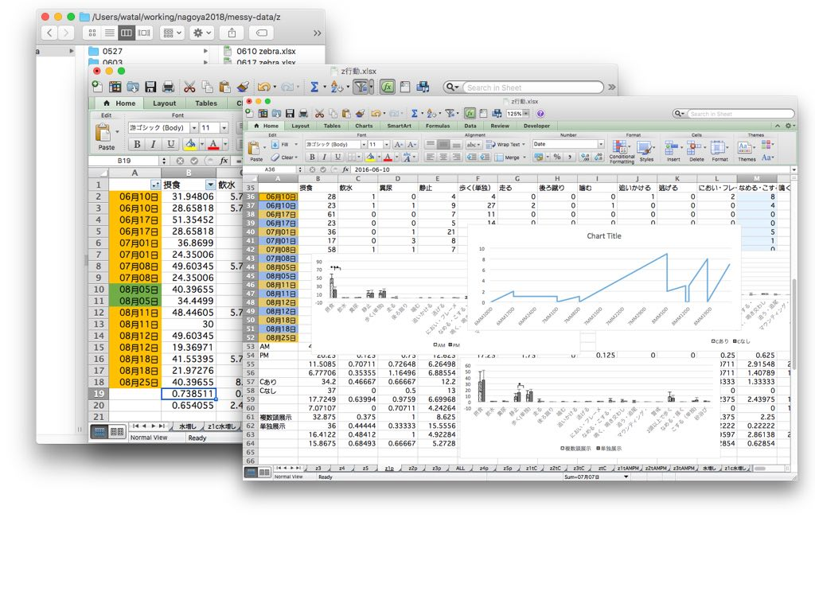

## 手動で数え、濃淡を計算し、 画像ソフトで塗る…

- 泣きながら何十枚も…。無料期間が終わって今は使えない…。

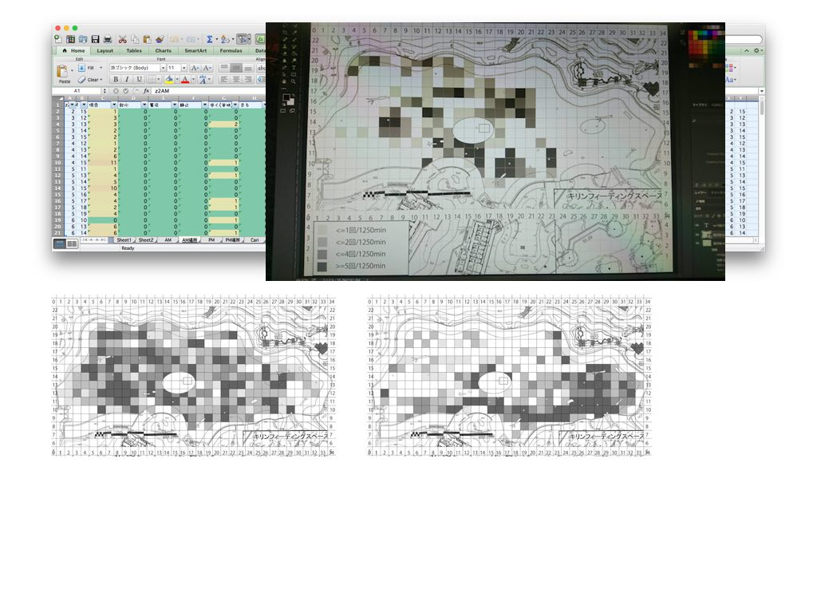

## 目作業・手作業 = シーシュボスの岩

- **膨大な単純作業**がそもそもツラい
- 人間だもの、**ミスは防ぎきれない**
- ミスを防ぐためのチェックもツラい
- ミスを発見 → **初めからやり直し**
- 新たなデータ・研究 → **初めからやり直し**
- 熟練してもツラいまま

[figure not shown]

https://en.wikipedia.org/wiki/Sisyphus

- その時の自分しかできない、記録に残らない  
  →**検証のしようがない**
- 卒論なら努力賞で良いかもだけど、科学の手続きとしては問題

## プログラミングで大量のファイルを捌く

- 先の例に負けず生データはどっさり。でも頑張るのは機械。

[figure not shown]

## プログラミングで再現性の良い研究を！

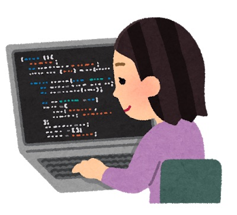

- 規則性のある退屈な仕事は人間よりも機械の方が得意
- 一度書いたプログラムは、データが変わっても**使いまわせる**
- **自分以外の人でも再現・検証**できる
- **きれいな図を簡単に**かける
- 部分的に改変しながらいろんな解析を試せる。  
  → **仮説検証**だけなく、**仮説生成（探索的データ解析）**にも良い
- やれば上達する！どんどん楽になる！！

## Rとは

[figure not shown]

統計解析と作図の機能が充実したプログラミング言語

### **クロスプラットフォーム**

- Linux, Mac, Windowsで動く。

### **オープンソース**

- 永久に無償で、すべての機能を使える。
- 集合知によって常に進化している。

### **コミュニティ**

- 相談できる人や参考になるウェブサイトがたくさん見つかる。  
  他のプログラミング言語でもできなくはない。Pythonもいい。

## 本実習の目標

### **科学的なデータ解析の基本を身につける**

- 解析しやすいデータの形
- 再現可能な解析方法

### **必要な解析方法を調べ、実践する方法を知る**

- 困ったらどうしたら良いか

### **これさえ押さえれば、具体的なやり方は覚えなくてOK**

## Rと接する上での心構え

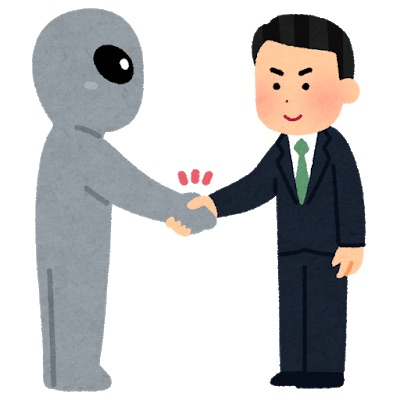

### **エラー文を恐れない**

#### 熟練したプログラマーでエラーは当たり前。エラー文はRさんからのメッセージ。まずは落ち着いてエラー文を読んで、コードを書きなおしてみよう。

### **困ったらググる**

#### Rは全世界にユーザーがいるので、自分が困っていることは、必ず誰かが解決している。困ったら、日本語で、英語で、エラー文で、ググって調べると解決策が見つかるはず！

## プログラミングの身につけ方

### **とにかく手を動かして体感すること！**

1. コードはコピペして手元で動かしてみよう
2. 動いたら、自分用に改変しよう（引用も忘れずに）
   - 動かなかったらエラーコードを見ながら動くまで試行錯誤
3. 改変したコードが動かなかったら、何が悪いのか調べよう
   - コードやデータをよく見比べる

### **エラーを解決した経験値 = プログラミングの経験値**

- エラーを恐れずどんどん書こう！

### 困ったら…

- ググる／TAさんに訊く／よくあるエラー集を見る

## この実習の取り組み方（1/2）

### 1. この枠が出てきたらコピペして自分のPCで走らせる

- （やり方はこのあと教えます）

```r
head(iris)
```

### 2. コンソールを確認する

- 思ったとおりの出力が出てきたか？
- ErrorやWarning（赤文字）が出ていたらよく読んで対応する
  - 問題ないWarningもあるのでよく読んで

### 3. [練習問題]はまず答えを見ずに自分でコードを書いてみる

- これまでのコードをコピペして改変すればできるはず

## この実習の取り組み方（2/2）

### 4. 自分のデータをとる（自由課題）

### 5. スライドを見直して、使えそうな方法で解析する

- ErrorやWarning（赤文字）が出たら何とか解決する
- 前半の演習部分でのエラー経験がここで生きてくる（はず）！

## さっそく使ってみよう！

### RStudioのアイコンをダブルクリック！

[figure not shown]

## RStudioの設定を確認！

- Win: Tools → Global options
- Mac: RStudio → References

[figure not shown]

## プロジェクトを作ろう！

- まずは「プロジェクト」を作成する
- 以下の順でクリックして進む
  - File → New Project → New Directory → New Project → Create New Project
- Directory Nameは「R_training_2021」と入力

[figure not shown]

## 基本１：スクリプトに書いてから実行

- 以下の順でクリックして進む
  - File → New File → R Script

[figure not shown]

## 基本１：スクリプトに書いてから実行

- 以下の順でクリックして進む
  - File → New File → R Script

[figure not shown]

## 基本２：スクリプトを保存する

- 以下の順でクリックして進む
  - File → Save
  - ファイル名は「R_training_2021_script」
  - 場所はさっき作ったプロジェクト（フォルダ）の中
  - 保存されている場所を確かめておこう
- **スクリプトを書いたら消さずに保存すること！**
  - 書いた／集めたスクリプトは財産
  - 保存しておけばまた使い回せる

## 基本３：Rと会話する

- まずは１＋１から！
- スクリプトに1 + 1と書く → 1 + 1を選択 → Ctrl + Enter
- **コンソールに入れないとRに伝わらない**

[figure not shown]

## 基本３：Rと会話する

できた人は･･･

### ［練習問題］

- 1 + 2 + 3
- 3 * 7 * 2
- 4 ÷ 2
- 4 ÷ 3
- 他にも好きな計算をしてみよう！

## 覚えておくと役立つこと(1)

- 記号の前後にはスペースを空けるクセをつけよう！
- **1+1** ←Bad
- **1 + 1** ←Good!!
- コードが見やすくなり、間違いが起こりにくい！

## 覚えておくと役立つこと(2)

- ショートカットを使いこなそう！

[figure not shown]

## 変数を使ってみよう！

### **変数に値を代入する** ※代入演算子は 「=」「<-」

```r
x = 2          #xに2を代入
x              #xは何か訊く
```

- スクリプトを書くだけでは何も起こらないので
- **選択した状態で Ctrl + Enter**してコンソールへ渡す！
- 「#」をつけるとRは無視してくれます。メモを書くのに便利。

## 変数を使ってみよう！

### **変数に値を代入する** ※代入演算子は 「=」「<-」

```r
x = 2          #xに2を代入
x              #xってなんだっけ？
```

```
## [1] 2
```

- ↑ こういう結果がコンソールに表示されるはず
- 今後、コードと結果はこのように示します！

## 変数を使ってみよう！

### **変数に値を代入する** ※代入演算子は 「=」「<-」

```r
x = 2          #xに2を代入
x              #xってなんだっけ？
```

```
## [1] 2
```

```r
y = 5          #yに5を代入
y              #yってなんだっけ？
```